# Telco Customer Churn Analysis

## Initial Data Exploration

[output not shown]

### High-level overview of the data

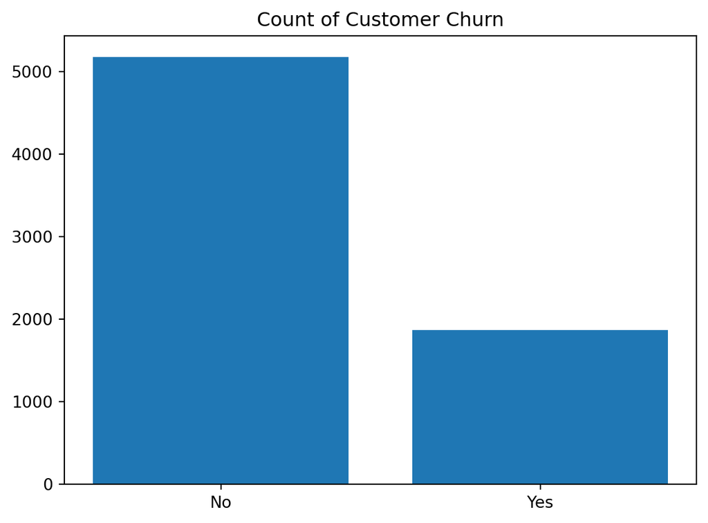

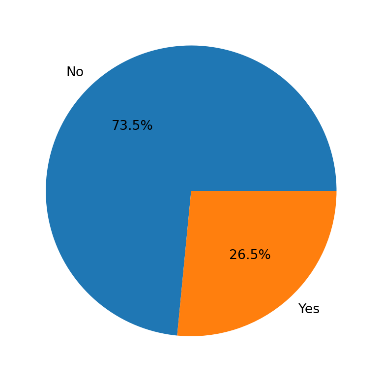

## Understanding the data that causes churn

### Numeric Features

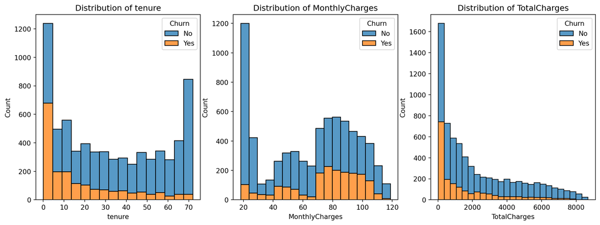

The most likely customers to churn are ones that have been with the company for a short period of time, and have higher monthly charges.

The more money someone has spent with us, the less likely they are to churn.

### Categorical Features

In these bar charts we observe a few different insights

- Gender has little to no impact on churn
- Seniors are more likely to churn
- Customers without partners or dependents are more likely to churn
- Phone Service has little to no impact on churn
- Customers with Fiber Optic Internet Service are significantly more likely to churn
- Customers with Month-to-Month contracts are significantly more likely to churn

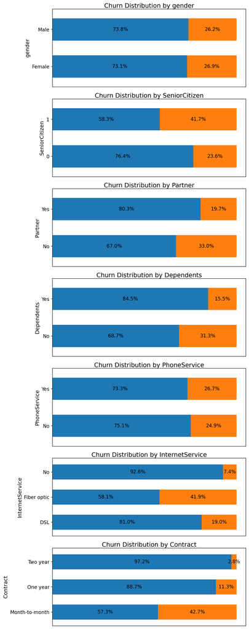

### Why might internet service matter?

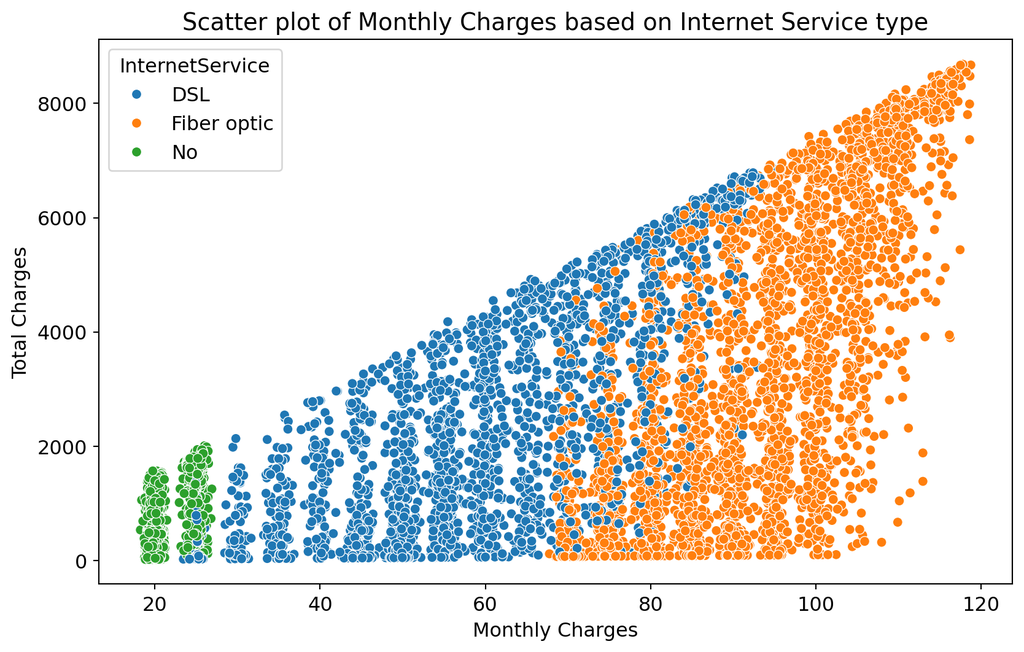

Customers with Fiber optic internet service have higher monthly charges. This could be a reason why they are more likely to churn.

### Looking at Churn by type of Contract

As can be seen in the graphs below, customers with month-to-month contracts are significantly more likely to churn compared to customers with one or two year contracts.

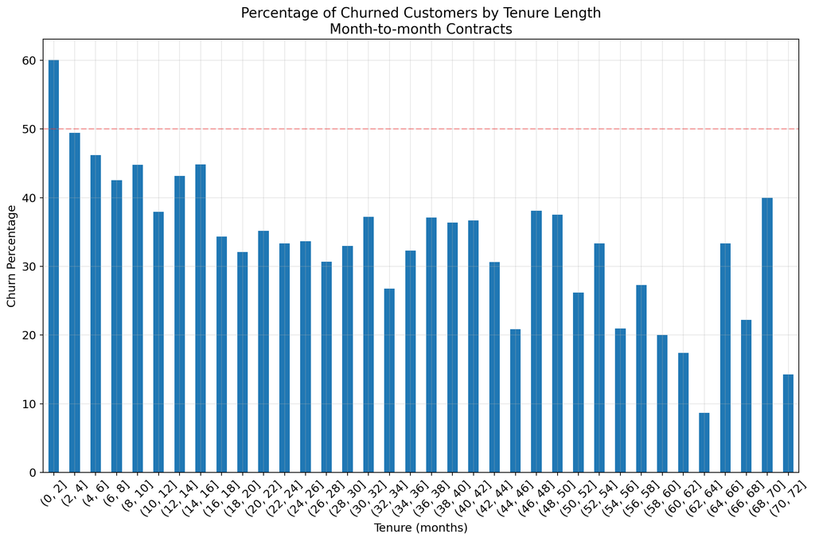

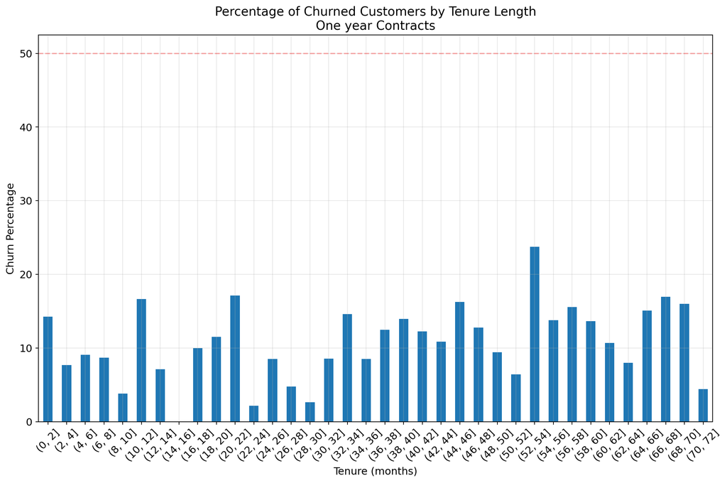

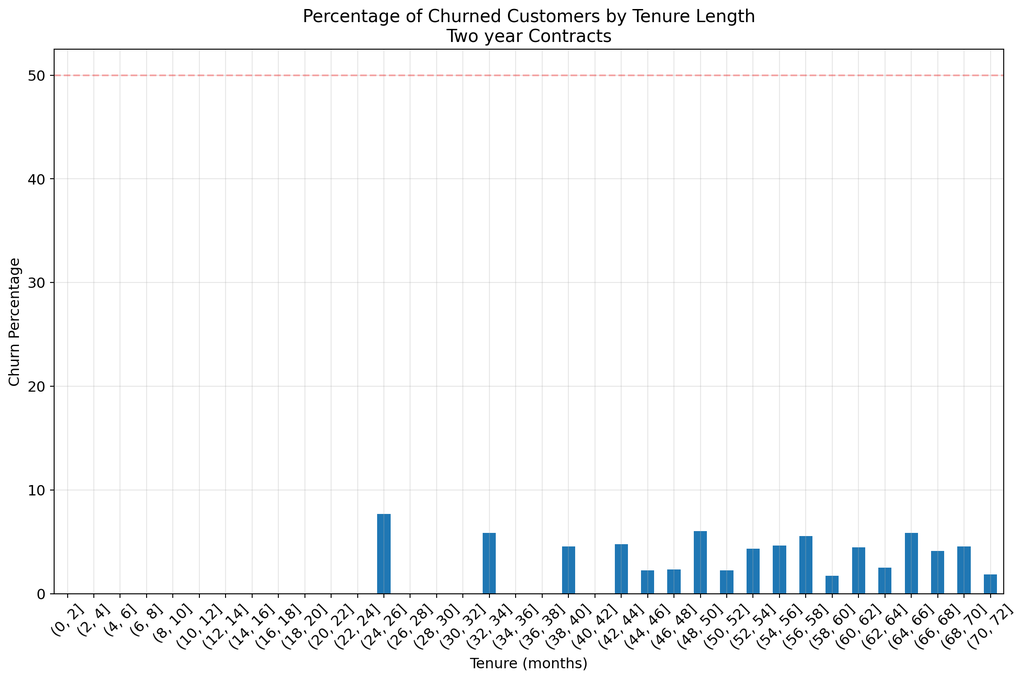

# Recommendations

Based on our analysis, we have identified a few key areas that are driving churn:

- **Tenure**: Customers who have been with the company for a short period of time are more likely to churn
- **Monthly Charges**: Customers with higher monthly charges are more likely to churn
- **Contract Type**: Customers with month-to-month contracts are significantly more likely to churn

To reduce churn, we recommend the following:

- **Promote longer contracts**: Encourage customers to sign up for longer contracts by offering discounts or other incentives
- **Reduce monthly charges**: Consider offering lower-priced plans to customers who are at risk of churning
- **Improve customer service**: Provide better customer service to customers who are at risk of churning to increase customer satisfaction. Spend more time with customers early on to help them understand the value of the service.

Next steps from Alpha Consulting:

- **Predictive modeling**: Build a predictive model to identify customers who are at risk of churning. This will allow us to take proactive steps to retain these customers.